# 5243-1st-Assignment-yc4369

While the tendency of mentioning words are similar between men and women, the weights of mentioning might be different. We can take a look at the words frequency bar charts and examine the frequency of most mentioned words.

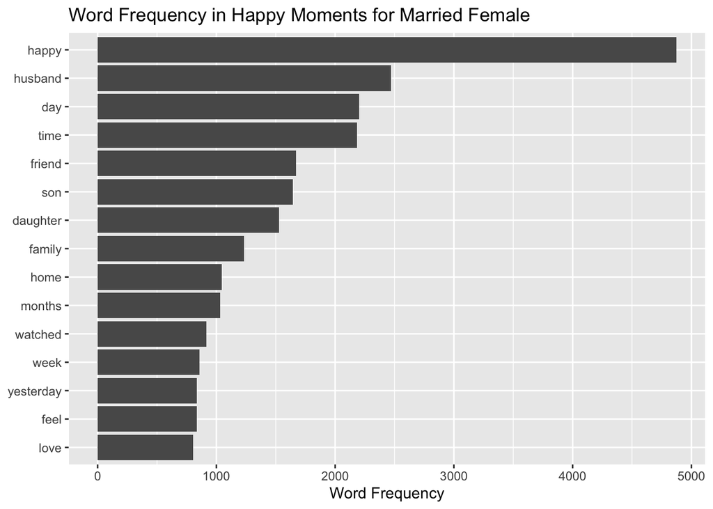

```r
word_count_married_f[1:15,] %>%
  mutate(word = reorder(word, n)) %>%
  ggplot(aes(word, n)) +
  geom_col() +
  labs(title = "Word Frequency in Happy Moments for Married Female")+
  xlab(NULL) +
  ylab("Word Frequency")+
  coord_flip()
```

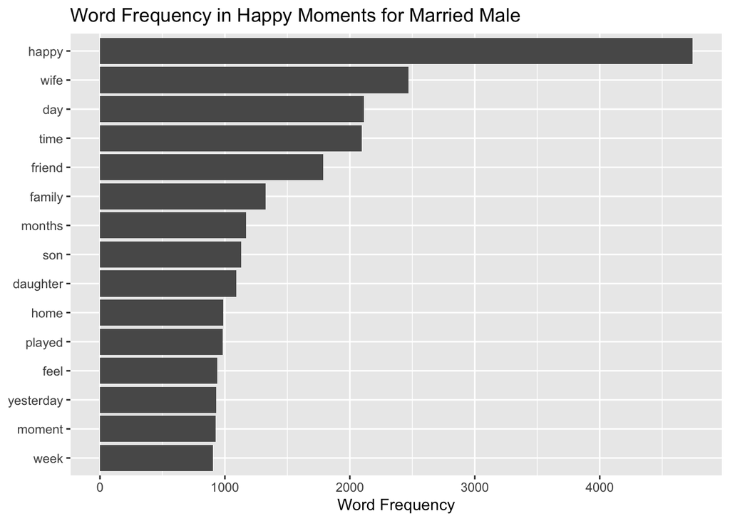

```r
word_count_married_m[1:15,] %>%
  mutate(word = reorder(word, n)) %>%
  ggplot(aes(word, n)) +
  geom_col() +
  labs(title ="Word Frequency in Happy Moments for Married Male")+
  xlab(NULL) +
  ylab("Word Frequency")+
  coord_flip()
```

- Conclusion: Both married men and women gain lots of happiness from their family members. Especially, the fact that married couples mention their wives and husbands the most is a notable result.